# Potential Talents Project

## Background:

As a talent sourcing and management company, we are interested in finding talented individuals for sourcing these candidates to technology companies. Finding talented candidates is not easy, for several reasons. The first reason is one needs to understand what the role is very well to fill in that spot, this requires understanding the client’s needs and what they are looking for in a potential candidate. The second reason is one needs to understand what makes a candidate shine for the role we are in search for. Third, where to find talented individuals is another challenge.

The nature of our job requires a lot of human labor and is full of manual operations. Towards automating this process we want to build a better approach that could save us time and finally help us spot potential candidates that could fit the roles we are in search for. Moreover, going beyond that for a specific role we want to fill in we are interested in developing a machine learning powered pipeline that could spot talented individuals, and rank them based on their fitness.

We are right now semi-automatically sourcing a few candidates, therefore the sourcing part is not a concern at this time but we expect to first determine best matching candidates based on how fit these candidates are for a given role. We generally make these searches based on some keywords such as “full-stack software engineer”, “engineering manager” or “aspiring human resources” based on the role we are trying to fill in. These keywords might change, and you can expect that specific keywords will be provided to you.

Assuming that we were able to list and rank fitting candidates, we then employ a review procedure, as each candidate needs to be reviewed and then determined how good a fit they are through manual inspection. This procedure is done manually and at the end of this manual review, we might choose not the first fitting candidate in the list but maybe the 7th candidate in the list. If that happens, we are interested in being able to re-rank the previous list based on this information. This supervisory signal is going to be supplied by starring the 7th candidate in the list. Starring one candidate actually sets this candidate as an ideal candidate for the given role. Then, we expect the list to be re-ranked each time a candidate is starred.

## Data Description:

The data comes from our sourcing efforts. We removed any field that could directly reveal personal details and gave a unique identifier for each candidate.

Attributes: id : unique identifier for candidate (numeric) job_title : job title for candidate (text) location : geographical location for candidate (text) connections: number of connections candidate has, 500+ means over 500 (text) Output (desired target): fit - how fit the candidate is for the role? (numeric, probability between 0-1) Keywords: “Aspiring human resources” or “seeking human resources”

Download Data:

https://docs.google.com/spreadsheets/d/117X6i53dKiO7w6kuA1g1TpdTlv1173h_dPlJt5cNNMU/edit?usp=sharing

## Goal(s):

Predict how fit the candidate is based on their available information (variable fit) Success Metric(s):

Rank candidates based on a fitness score. Re-rank candidates when a candidate is starred. Bonus(es):

We are interested in a robust algorithm, tell us how your solution works and show us how your ranking gets better with each starring action. How can we filter out candidates which in the first place should not be in this list? Can we determine a cut-off point that would work for other roles without losing high potential candidates? Do you have any ideas that we should explore so that we can even automate this procedure to prevent human bias?

```python
import pandas as pd
import numpy as np
import os
import random
from itertools import combinations

from sklearn.feature_extraction.text import TfidfVectorizer, CountVectorizer
from scipy.spatial.distance import cosine
from sentence_transformers import SentenceTransformer
from sklearn.model_selection import train_test_split

import tensorflow as tf

import nltk
from nltk.stem import WordNetLemmatizer
from nltk.corpus import stopwords
from nltk.tokenize import word_tokenize
import string

from IPython.display import display
import matplotlib.pyplot as plt
from wordcloud import WordCloud
from unidecode import unidecode
from nltk.stem import WordNetLemmatizer
from gensim.models import Word2Vec
```

```python
# Random seeding to ensure results are reproduced
seed_value=42
os.environ['PYTHONHASHSEED']=str(seed_value)
np.random.seed(seed_value)
random.seed(seed_value)
```

```python
# copying data to another varaible to avoid any changes to original data
data = pd.read_csv("potential-talents - Aspiring human resources - seeking human resources.csv")
```

```python
data.shape
```

```
(104, 5)
```

```python
df = data.copy()
```

```python
df.columns
```

```
Index(['id', 'job_title', 'location', 'connection', 'fit'], dtype='object')
```

```python
df.head()
```

|  | id | job_title | location | connection | fit |
| --- | --- | --- | --- | --- | --- |
| 0 | 1 | 2019 C.T. Bauer College of Business Graduate (... | Houston, Texas | 85 | NaN |
| 1 | 2 | Native English Teacher at EPIK (English Progra... | Kanada | 500+ | NaN |
| 2 | 3 | Aspiring Human Resources Professional | Raleigh-Durham, North Carolina Area | 44 | NaN |
| 3 | 4 | People Development Coordinator at Ryan | Denton, Texas | 500+ | NaN |
| 4 | 5 | Advisory Board Member at Celal Bayar University | İzmir, Türkiye | 500+ | NaN |

```python
df.tail()
```

|  | id | job_title | location | connection | fit |
| --- | --- | --- | --- | --- | --- |
| 99 | 100 | Aspiring Human Resources Manager \| Graduating ... | Cape Girardeau, Missouri | 103 | NaN |
| 100 | 101 | Human Resources Generalist at Loparex | Raleigh-Durham, North Carolina Area | 500+ | NaN |
| 101 | 102 | Business Intelligence and Analytics at Travelers | Greater New York City Area | 49 | NaN |
| 102 | 103 | Always set them up for Success | Greater Los Angeles Area | 500+ | NaN |
| 103 | 104 | Director Of Administration at Excellence Logging | Katy, Texas | 500+ | NaN |

```python
df.info()
```

```
<class 'pandas.core.frame.DataFrame'>
RangeIndex: 104 entries, 0 to 103
Data columns (total 5 columns):
 #   Column      Non-Null Count  Dtype
---  ------      --------------  -----
 0   id          104 non-null    int64
 1   job_title   104 non-null    object
 2   location    104 non-null    object
 3   connection  104 non-null    object
 4   fit         0 non-null      float64
dtypes: float64(1), int64(1), object(3)
memory usage: 4.2+ KB
```

```python
#some basic stats for categorical columns
df.describe(include=object)
```

|  | job_title | location | connection |
| --- | --- | --- | --- |
| count | 104 | 104 | 104 |
| unique | 52 | 41 | 33 |
| top | 2019 C.T. Bauer College of Business Graduate (... | Kanada | 500+ |
| freq | 7 | 12 | 44 |

```python
#let us first drop duplicates, if there are any, from the dataset
df.drop_duplicates(inplace=True)
```

```python
# Define helper functions and classes

def pre_processing(text_to_preprocess):
    """
    Lemmatize, remove stopwords digits and special characters, replace abbreviations, returns the processed text
    """
    cleaned_text = []
    lemmatizer = WordNetLemmatizer()
    for text in text_to_preprocess:
        processed_text = ' '.join([word.lower() for word in word_tokenize(text)])
        processed_text = ''.join([word.translate(str.maketrans('', '', string.punctuation)) for word in processed_text])
        processed_text = ''.join([i for i in processed_text if not i.isdigit()])
        processed_text = ' '.join([word for word in processed_text.split() if not word in stopwords.words('english')])
        processed_text = ' '.join( [w for w in processed_text.split() if len(w)>1])
        processed_text = [lemmatizer.lemmatize(word) for word in nltk.word_tokenize(processed_text)]
        processed_text = ' '.join([i for i in processed_text])
        cleaned_text.append(processed_text)
    return cleaned_text

def clean_phrase(phrase):
    lemmatizer = WordNetLemmatizer()
    X = [lemmatizer.lemmatize(word) for word in word_tokenize(phrase.lower())]
    X = ' '.join([i for i in X])
    return X


def check_similarity(column_name, embeddings, X_search):
    copy_df = df.copy()

    score_list = []
    for i in range(len(df)):
        score_list.append(1 - cosine(embeddings[i], X_search))

    copy_df[column_name] = score_list
    display(copy_df.sort_values(by = column_name, ascending=False, ignore_index=True).head(10))
    return score_list

def generate_word_cloud(column):
    job_text = " ".join(item for item in column)
    plt.figure(figsize=(10, 5))
    word_cloud = WordCloud(max_font_size=50, max_words=100,
                           collocations=False, background_color="#b3cccc",).generate(job_text)
    plt.imshow(word_cloud, interpolation='bilinear')
    plt.axis("off")
    plt.show()

def plot_loss(data):
    plt.title("Loss v/s Epochs")
    plt.plot(data['loss'], label='Training_loss')
    plt.plot(data['val_loss'], label='Validation_loss')
    plt.xlabel("Training Epochs")
    plt.ylabel("Loss")
    plt.show()

class Ranknet(tf.keras.Model):

    def __init__(self):
        super().__init__()
        self.model = tf.keras.Sequential()
        self.model.add(tf.keras.layers.Input(shape=(768)))
        self.model.add(tf.keras.layers.Dense(800, activation='linear', name='layer_1'))
        self.model.add(tf.keras.layers.Dropout(rate=0.2, name='dropput_layer_1'))
        self.model.add(tf.keras.layers.Dense(1600, activation=tf.nn.leaky_relu, name='layer_2'))
        self.model.add(tf.keras.layers.Dropout(rate=0.2, name='dropput_layer_2'))
        self.model.add(tf.keras.layers.Dense(400, activation=tf.nn.leaky_relu, name='layer_3'))
        self.model.add(tf.keras.layers.Dense(1, activation='sigmoid', name='output_layer'))

    def call(self, docs):
        doc1, doc2 = docs
        s1 = self.model(doc1)
        s2 = self.model(doc2)
        output = tf.nn.sigmoid(s1 - s2)
        return output

    def predict(self, input_):
        s = self.model(input_)
        return s

    def build_graph(self):
        X = [ tf.keras.layers.Input(shape=(768)), tf.keras.layers.Input(shape=(768))]
        return tf.keras.Model(inputs=X,outputs=self.forward(X))
```

## Data Preparation and Analysis

```python
# Columns that are not required are removed
df.drop(['fit'], axis=1, inplace=True)
# df['connection'] = df['connection'].replace(['500+ '], '500')
print(df.shape)
df.head()
```

```
(104, 4)
```

|  | id | job_title | location | connection |
| --- | --- | --- | --- | --- |
| 0 | 1 | 2019 C.T. Bauer College of Business Graduate (... | Houston, Texas | 85 |
| 1 | 2 | Native English Teacher at EPIK (English Progra... | Kanada | 500+ |
| 2 | 3 | Aspiring Human Resources Professional | Raleigh-Durham, North Carolina Area | 44 |
| 3 | 4 | People Development Coordinator at Ryan | Denton, Texas | 500+ |
| 4 | 5 | Advisory Board Member at Celal Bayar University | İzmir, Türkiye | 500+ |

### Analysis of candidates based on location:

```
Total Unique locations:  41
```

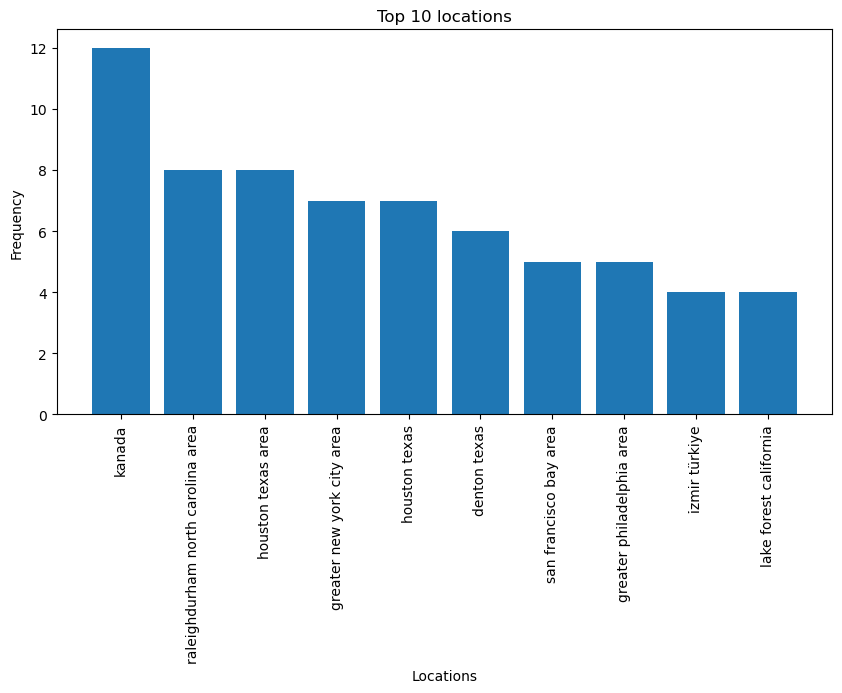

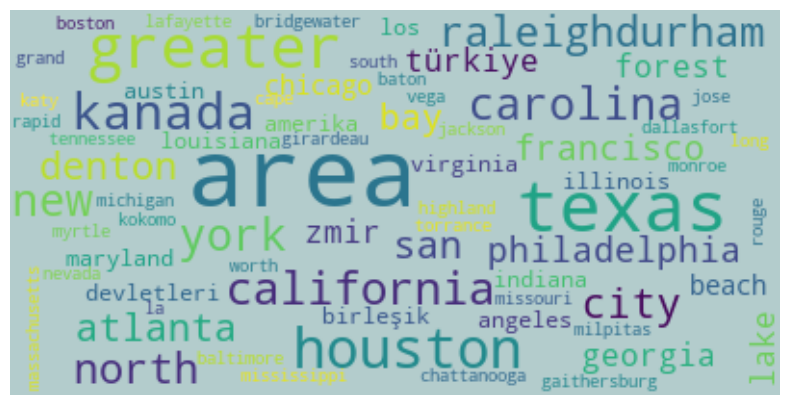

```python
df['location'] = pre_processing(df['location'])
print("Total Unique locations: ", len(df.location.value_counts()))

# Top 10 locations
plt.figure(figsize=(10, 5))
plt.bar(df.location.value_counts().index[: 10], df.location.value_counts()[: 10])
plt.xticks(rotation=90)
plt.title("Top 10 locations")
plt.xlabel("Locations")
plt.ylabel("Frequency")
plt.show()

generate_word_cloud(df['location'])
```

### Analysis of candidates' job titles:

We perform the following pre-processing steps on the text data in our dataset

```
Total Unique locations:  41
```

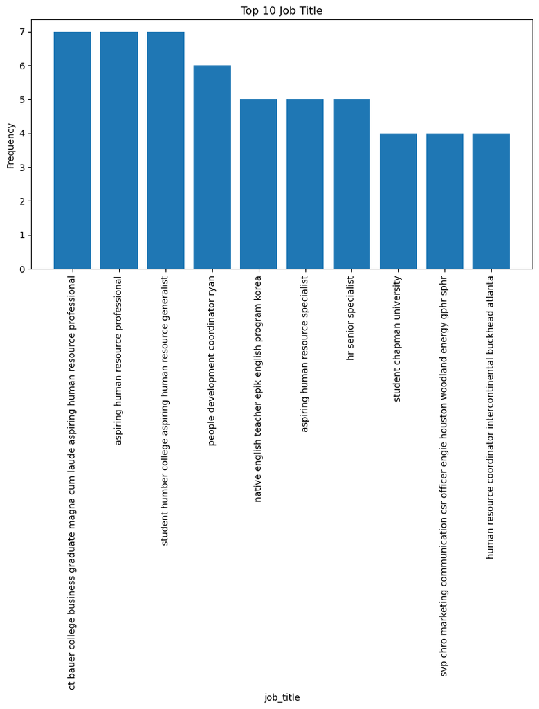

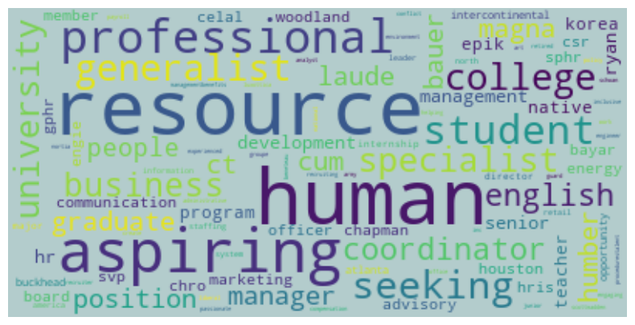

```python
df['job_title'] = pre_processing(df['job_title'])
print("Total Unique locations: ", len(df.location.value_counts()))

# Top 10 Job Titlea
plt.figure(figsize=(10, 5))
plt.bar(df.job_title.value_counts().index[: 10], df.job_title.value_counts()[: 10])
plt.xticks(rotation=90)
plt.title("Top 10 Job Title")
plt.xlabel("job_title")
plt.ylabel("Frequency")
plt.show()

generate_word_cloud(df['job_title'])
```

### Analysis of candidates' job titles:

We perform the following pre-processing steps on the text data in our dataset

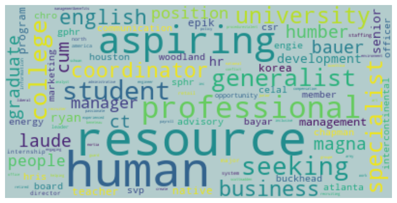

```
Top 10 frequently used words:
```

|  | Words | Frequency |
| --- | --- | --- |
| 9 | human | 63 |
| 10 | resource | 63 |
| 8 | aspiring | 35 |
| 11 | professional | 21 |
| 29 | student | 16 |
| 34 | seeking | 15 |
| 31 | generalist | 14 |
| 2 | college | 14 |
| 27 | university | 12 |
| 28 | specialist | 12 |

```python
df['job_title'] = pre_processing(df['job_title'])
#print("Total Unique locations: ", len(df.location.value_counts()))

generate_word_cloud(df['job_title'])

word_dict = {}

for val in df['job_title']:
    for word in val.split(" "):
        if word not in word_dict:
            word_dict[word] = 1
        else:
            word_dict[word] = word_dict[word] + 1

print("Top 10 frequently used words:")

pd.DataFrame({'Words': word_dict.keys(),
              'Frequency': word_dict.values()}).sort_values(by=['Frequency'], ascending=False).head(10)
```

**Dataset Preparation:** Duplicate rows are removed after the pre-processing steps.

```python
df.info()
```

```
<class 'pandas.core.frame.DataFrame'>
RangeIndex: 104 entries, 0 to 103
Data columns (total 4 columns):
 #   Column      Non-Null Count  Dtype
---  ------      --------------  -----
 0   id          104 non-null    int64
 1   job_title   104 non-null    object
 2   location    104 non-null    object
 3   connection  104 non-null    object
dtypes: int64(1), object(3)
memory usage: 3.4+ KB
```

```python
df = df[~df.drop(["id"], axis=1).duplicated()]
df.reset_index(inplace=True, drop=True)
print("Dataset Shape: ", df.shape)
display(df.head())

phrase_one = clean_phrase("Aspiring human resources")
print("Pre-processed query1: ", phrase_one)
phrase_two = clean_phrase("Seeking human resources")
print("Pre-processed query2: ", phrase_two)
```

```
Dataset Shape:  (53, 4)
```

|  | id | job_title | location | connection |
| --- | --- | --- | --- | --- |
| 0 | 1 | ct bauer college business graduate magna cum l... | houston texas | 85 |
| 1 | 2 | native english teacher epik english program korea | kanada | 500+ |
| 2 | 3 | aspiring human resource professional | raleighdurham north carolina area | 44 |
| 3 | 4 | people development coordinator ryan | denton texas | 500+ |
| 4 | 5 | advisory board member celal bayar university | i̇zmir türkiye | 500+ |

```
Pre-processed query1:  aspiring human resource
Pre-processed query2:  seeking human resource
```

```python
for i in range(53):
    print(df['job_title'][i])
```

```
ct bauer college business graduate magna cum laude aspiring human resource professional
native english teacher epik english program korea
aspiring human resource professional
people development coordinator ryan
advisory board member celal bayar university
aspiring human resource specialist
student humber college aspiring human resource generalist
hr senior specialist
seeking human resource hris generalist position
student chapman university
svp chro marketing communication csr officer engie houston woodland energy gphr sphr
human resource coordinator intercontinental buckhead atlanta
aspiring human resource management student seeking internship
seeking human resource opportunity
experienced retail manager aspiring human resource professional
human resource staffing recruiting professional
human resource specialist luxottica
director human resource north america groupe beneteau
retired army national guard recruiter office manager seeking position human resource
human resource generalist scottmadden inc
business management major aspiring human resource manager
aspiring human resource manager seeking internship human resource
human resource professional
nortia staffing seeking human resource payroll administrative professional
aspiring human resource professional passionate helping create inclusive engaging work environment
human resource conflict management policy procedurestalent managementbenefits compensation
human resource generalist schwan
liberal art major aspiring human resource analyst
junior engineer information system
senior human resource business partner heil environmental
aspiring human resource professional energetic teamfocused leader
hr manager endemol shine north america
human resource professional world leader gi software
rrp brand portfolio executive jti japan tobacco international
information system specialist programmer love data organization
bachelor science biology victoria university wellington
human resource management major
director human resource ey
undergraduate research assistant styczynski lab
lead official western illinois university
seeking employment opportunity within customer service patient care
admission representative community medical center long beach
seeking human resource opportunity open travel relocation
student westfield state university
student indiana university kokomo business management retail manager delphi hardware paint
aspiring human resource professional
student
seeking human resource position
aspiring human resource manager graduating may seeking entrylevel human resource position st louis
human resource generalist loparex
business intelligence analytics traveler
always set success
director administration excellence logging
```

```python
from collections import Counter

# Create a Counter to count word occurrences
words_counts = Counter()

# Iterate over each job title in the DataFrame
for i in df.job_title:
    # Split the job title into individual words
    for word in i.split(" "):
        # Update the word counts in the Counter
        words_counts[word] += 1

# Print the total number of unique words in the job title column
print('There are', len(words_counts), 'unique words in the job title column')

# Print the most common words and their counts
print(words_counts.most_common())
```

```
There are 175 unique words in the job title column
[('human', 34), ('resource', 34), ('aspiring', 13), ('professional', 10), ('seeking', 10), ('manager', 7), ('university', 6), ('student', 6), ('business', 5), ('generalist', 5), ('management', 5), ('specialist', 4), ('position', 4), ('opportunity', 3), ('director', 3), ('major', 3), ('college', 2), …
```

```python
# create a df with relevant columns

df = df[['id', 'job_title', 'location', 'connection']]
df.head()
```

|  | id | job_title | location | connection |
| --- | --- | --- | --- | --- |
| 0 | 1 | ct bauer college business graduate magna cum l... | houston texas | 85 |
| 1 | 2 | native english teacher epik english program korea | kanada | 500+ |
| 2 | 3 | aspiring human resource professional | raleighdurham north carolina area | 44 |
| 3 | 4 | people development coordinator ryan | denton texas | 500+ |
| 4 | 5 | advisory board member celal bayar university | i̇zmir türkiye | 500+ |

### Phase 1:

The goal of this phase is to build a model that provides the similarity score between job titles and queries. We will generate embeddings from the dataset using the following embedding techniques.

- TF-IDF cosine similarity
- BERT pre-trained model cosine similarity

We will rank the job titles based on the similarity scores obtained for different embedding techniques. We will select the best performing model from these techniques and use that for the next phase

### a. TF-IDF cosine similarity

TF-IDF matrix is generated for the dataset, similarly TF-IDF term for the queries are also generated. Cosine similarity score is used as the similarity metric to find job titles similar to the given queries.

```python
import pandas as pd
from tabulate import tabulate

# Sample DataFrame (replace this with your actual DataFrame)
data_query1 = {'id': [3, 97, 6, 73, 27, 72, 74, 66, 7, 100],
               'job_title': ['aspiring human resource professional', 'aspiring human resource professional', 'aspiring human resource specialist', 'aspiring human resource manager seeking intern...',
                             'aspiring human resource management student see...', 'business management major aspiring human resou...', 'human resource professional', 'experienced retail manager aspiring human reso...',
                             'student humber college aspiring human resource...', 'aspiring human resource manager graduating may...'],
               'location': ['raleighdurham north carolina area', 'kokomo indiana area', 'greater new york city area', 'houston texas area',
                            'houston texas area', 'monroe louisiana area', 'greater boston area', 'austin texas area', 'kanada', 'cape girardeau missouri'],
               'connection': [44, 71, 1, 7, 500, 5, 16, 57, 61, 103]}

data_query2 = {'id': [99, 28, 73, 10, 27, 74, 100, 94, 75, 3],
               'job_title': ['seeking human resource position', 'seeking human resource opportunity', 'aspiring human resource manager seeking intern...',
                             'seeking human resource hris generalist position', 'aspiring human resource management student see...', 'human resource professional',
                             'aspiring human resource manager graduating may...', 'seeking human resource opportunity open travel...', 'nortia staffing seeking human resource payroll...',
                             'aspiring human resource professional'],
               'location': ['la vega nevada area', 'chicago illinois', 'houston texas area', 'greater philadelphia area',
                            'houston texas area', 'greater boston area', 'cape girardeau missouri', 'amerika birleşik devletleri',
                            'san jose california', 'raleighdurham north carolina area'],
               'connection': [48, 390, 7, 500, 500, 16, 103, 415, 500, 44]}

df_query1 = pd.DataFrame(data_query1)
df_query2 = pd.DataFrame(data_query2)

# Cosine similarity scores for each query
similarity_scores_query1 = [0.773149, 0.773149, 0.682828, 0.623759, 0.440969, 0.438591, 0.422027, 0.412112, 0.397799, 0.383139]
similarity_scores_query2 = [0.703142, 0.680080, 0.638222, 0.466750, 0.466560, 0.398880, 0.392023, 0.374791, 0.355488, 0.326290]

# Add the cosine similarity scores as new columns
df_query1['tf_idf_cosine_sim_query1'] = similarity_scores_query1
df_query2['tf_idf_cosine_sim_query2'] = similarity_scores_query2

# Display the DataFrames in tabular format
print("Top 10 candidates for the job title: seeking human resource")
print(tabulate(df_query1, headers='keys', tablefmt='pretty', showindex=False))

print("\nTop 10 candidates for the job title: aspiring human resource")
print(tabulate(df_query2, headers='keys', tablefmt='pretty', showindex=False))
```

[output not shown]

From the results, we can observe that we get relevant results from the tf-idf cosine similarity approach for both queries. However, we will look at other techniques which can give better similarity score.

### b. BERT pre-trained model cosine similarity

Pre-trained BERT model is used to generate embeddings and cosine similarity is used to find similar job titles based on the queries.

```python
# BERT Model

s_embedder = SentenceTransformer('all-mpnet-base-v2')
# s_embedder = SentenceTransformer('bert-base-nli-mean-tokens')
bert_embeddings = s_embedder.encode(df.job_title)

print(bert_embeddings.shape)

X_search_one = s_embedder.encode(phrase_one)
X_search_two = s_embedder.encode(phrase_two)

print("Top 10 candidates for the job title:", phrase_one)
bert_similarity_query1 = check_similarity("BERT_cosine_sim_query1", bert_embeddings, X_search_one)
print("Top 10 candidates for the job title:", phrase_two)
bert_similarity_query2 = check_similarity("BERT_cosine_sim_query2", bert_embeddings, X_search_two)
```

```
(53, 768)
Top 10 candidates for the job title: aspiring human resource
```

|  | id | job_title | location | connection | BERT_cosine_sim_query1 |
| --- | --- | --- | --- | --- | --- |
| 0 | 3 | aspiring human resource professional | raleighdurham north carolina area | 44 | 0.880905 |
| 1 | 97 | aspiring human resource professional | kokomo indiana area | 71 | 0.880905 |
| 2 | 6 | aspiring human resource specialist | greater new york city area | 1 | 0.877840 |
| 3 | 74 | human resource professional | greater boston area | 16 | 0.754004 |
| 4 | 82 | aspiring human resource professional energetic... | austin texas area | 174 | 0.729662 |
| 5 | 67 | human resource staffing recruiting professional | jackson mississippi area | 500+ | 0.717234 |
| 6 | 72 | business management major aspiring human resou... | monroe louisiana area | 5 | 0.705096 |
| 7 | 73 | aspiring human resource manager seeking intern... | houston texas area | 7 | 0.701774 |
| 8 | 7 | student humber college aspiring human resource... | kanada | 61 | 0.701407 |
| 9 | 76 | aspiring human resource professional passionat... | new york new york | 212 | 0.693466 |

```
Top 10 candidates for the job title: seeking human resource
```

|  | id | job_title | location | connection | BERT_cosine_sim_query2 |
| --- | --- | --- | --- | --- | --- |
| 0 | 28 | seeking human resource opportunity | chicago illinois | 390 | 0.881616 |
| 1 | 99 | seeking human resource position | la vega nevada area | 48 | 0.838536 |
| 2 | 67 | human resource staffing recruiting professional | jackson mississippi area | 500+ | 0.810194 |
| 3 | 6 | aspiring human resource specialist | greater new york city area | 1 | 0.728420 |
| 4 | 10 | seeking human resource hris generalist position | greater philadelphia area | 500+ | 0.712926 |
| 5 | 74 | human resource professional | greater boston area | 16 | 0.705744 |
| 6 | 73 | aspiring human resource manager seeking intern... | houston texas area | 7 | 0.685609 |
| 7 | 3 | aspiring human resource professional | raleighdurham north carolina area | 44 | 0.672487 |
| 8 | 97 | aspiring human resource professional | kokomo indiana area | 71 | 0.672487 |
| 9 | 101 | human resource generalist loparex | raleighdurham north carolina area | 500+ | 0.661799 |

From the results, we can observe that we get relevant results from the BERT pre-trained model cosine similarity for both queries.

### Phase 2:

The BERT model embeddings are identified as the best way to rank the candidates. HR is given an option to bookmark certain candidates from the list of candidates. A new fitness score based on the previous similarity score and user selection is calculated and a neural network is developed that will re-rank the models based on the fitness score.

### Re-ranking candidates for query1:

```python
df['Fitness_score_query1'] = bert_similarity_query1
usr_selection = input("Would you like to bookmark certain candidates for query1: ")
if usr_selection == 'yes':
    star_list = input("List all the candidates to bookmark (Separated by a comma): ")
    for i in star_list.split(" "):
        df.loc[df['id']==int(i), 'Fitness_score_query1'] = 1

df.head(10)
```

```
Would you like to bookmark certain candidates for query1: yes
List all the candidates to bookmark (Separated by a comma): 19
```

|  | id | job_title | location | connection | Fitness_score_query1 |
| --- | --- | --- | --- | --- | --- |
| 0 | 1 | ct bauer college business graduate magna cum l... | houston texas | 85 | 0.679303 |
| 1 | 2 | native english teacher epik english program korea | kanada | 500+ | 0.309570 |
| 2 | 3 | aspiring human resource professional | raleighdurham north carolina area | 44 | 0.880905 |
| 3 | 4 | people development coordinator ryan | denton texas | 500+ | 0.529167 |
| 4 | 5 | advisory board member celal bayar university | i̇zmir türkiye | 500+ | 0.356170 |
| 5 | 6 | aspiring human resource specialist | greater new york city area | 1 | 0.877840 |
| 6 | 7 | student humber college aspiring human resource... | kanada | 61 | 0.701407 |
| 7 | 8 | hr senior specialist | san francisco bay area | 500+ | 0.603526 |
| 8 | 10 | seeking human resource hris generalist position | greater philadelphia area | 500+ | 0.574739 |
| 9 | 11 | student chapman university | lake forest california | 2 | 0.343272 |

### Re-ranking candidates for query2:

```python
df['Fitness_score_query2'] = bert_similarity_query2
usr_selection = input("Would you like to bookmark certain candidates for query2: ")
if usr_selection == 'yes':
    star_list = input("List all the candidates to bookmark (Separated by a comma): ")
    for i in star_list.split(" "):
        df.loc[df['id']==int(i), 'Fitness_score_query2'] = 1

df.head(10)
```

```
Would you like to bookmark certain candidates for query2: yes
List all the candidates to bookmark (Separated by a comma): 19
```

|  | id | job_title | location | connection | Fitness_score_query1 | Fitness_score_query2 |
| --- | --- | --- | --- | --- | --- | --- |
| 0 | 1 | ct bauer college business graduate magna cum l... | houston texas | 85 | 0.679303 | 0.509758 |
| 1 | 2 | native english teacher epik english program korea | kanada | 500+ | 0.309570 | 0.252325 |
| 2 | 3 | aspiring human resource professional | raleighdurham north carolina area | 44 | 0.880905 | 0.672487 |
| 3 | 4 | people development coordinator ryan | denton texas | 500+ | 0.529167 | 0.505585 |
| 4 | 5 | advisory board member celal bayar university | i̇zmir türkiye | 500+ | 0.356170 | 0.298487 |
| 5 | 6 | aspiring human resource specialist | greater new york city area | 1 | 0.877840 | 0.728420 |
| 6 | 7 | student humber college aspiring human resource... | kanada | 61 | 0.701407 | 0.640132 |
| 7 | 8 | hr senior specialist | san francisco bay area | 500+ | 0.603526 | 0.598001 |
| 8 | 10 | seeking human resource hris generalist position | greater philadelphia area | 500+ | 0.574739 | 0.712926 |
| 9 | 11 | student chapman university | lake forest california | 2 | 0.343272 | 0.271468 |

```python
display(df.sort_values(by = 'Fitness_score_query2', ascending=False, ignore_index=True).head(20))
```

|  | id | job_title | location | connection | Fitness_score_query1 | Fitness_score_query2 |
| --- | --- | --- | --- | --- | --- | --- |
| 0 | 28 | seeking human resource opportunity | chicago illinois | 390 | 0.687967 | 0.881616 |
| 1 | 99 | seeking human resource position | la vega nevada area | 48 | 0.633556 | 0.838536 |
| 2 | 67 | human resource staffing recruiting professional | jackson mississippi area | 500+ | 0.717234 | 0.810194 |
| 3 | 6 | aspiring human resource specialist | greater new york city area | 1 | 0.877840 | 0.728420 |
| 4 | 10 | seeking human resource hris generalist position | greater philadelphia area | 500+ | 0.574739 | 0.712926 |
| 5 | 74 | human resource professional | greater boston area | 16 | 0.754004 | 0.705744 |
| 6 | 73 | aspiring human resource manager seeking intern... | houston texas area | 7 | 0.701774 | 0.685609 |
| 7 | 3 | aspiring human resource professional | raleighdurham north carolina area | 44 | 0.880905 | 0.672487 |
| 8 | 97 | aspiring human resource professional | kokomo indiana area | 71 | 0.880905 | 0.672487 |
| 9 | 101 | human resource generalist loparex | raleighdurham north carolina area | 500+ | 0.612809 | 0.661799 |
| 10 | 89 | director human resource ey | greater atlanta area | 349 | 0.658843 | 0.657378 |
| 11 | 13 | human resource coordinator intercontinental bu... | atlanta georgia | 500+ | 0.589792 | 0.653293 |
| 12 | 75 | nortia staffing seeking human resource payroll... | san jose california | 500+ | 0.522961 | 0.650629 |
| 13 | 7 | student humber college aspiring human resource... | kanada | 61 | 0.701407 | 0.640132 |
| 14 | 71 | human resource generalist scottmadden inc | raleighdurham north carolina area | 500+ | 0.540031 | 0.637483 |
| 15 | 68 | human resource specialist luxottica | greater new york city area | 500+ | 0.596885 | 0.631378 |
| 16 | 27 | aspiring human resource management student see... | houston texas area | 500+ | 0.627566 | 0.623248 |
| 17 | 82 | aspiring human resource professional energetic... | austin texas area | 174 | 0.729662 | 0.622092 |
| 18 | 66 | experienced retail manager aspiring human reso... | austin texas area | 57 | 0.672274 | 0.618203 |
| 19 | 83 | hr manager endemol shine north america | los angeles california | 268 | 0.539229 | 0.615049 |

### Observation:

From the result above, BERT technique appears to be more effective for ranking the talents and would be adopted. It is important to note that BERT's performance is due to it's pretrained large corpus of unlabelled text including the entire Wikipedia(that’s 2,500 million words!) and Book Corpus (800 million words).

### Re-ranking Candidates after starring

- Re-rank using the job title starred as keyword and finding its cosine similarity to all the other job titles.
- For this task Bert Embeddings vectors will be used.

```python
index = df.index
print('Candidate Ids list')
for i in index:
    print(i,end=' ')
```

```
Candidate Ids list
0 1 2 3 4 5 6 7 8 9 10 11 12 13 14 15 16 17 18 19 20 21 22 23 24 25 26 27 28 29 30 31 32 33 34 35 36 37 38 39 40 41 42 43 44 45 46 47 48 49 50 51 52
```

```python
starred_id = input("Please, enter id of starred candidate(s): ")
```

```
Please, enter id of starred candidate(s): 19
```

```python
# Build BERT_base model and get Bert vectors

bert_model = SentenceTransformer('bert-base-nli-mean-tokens')
rerank_key = df[df.index.isin([int(starred_id)])]['job_title'].tolist()
bert_vectors_rerank = bert_model.encode(list(df['job_title']))
rerank_vectors = bert_model.encode(rerank_key)
```

```python
# Cosine similarity

from sklearn.metrics.pairwise import cosine_similarity
import numpy as np

RerankScore = []

# Loop through the vectors in bert_vectors_rerank
for i in range(len(bert_vectors_rerank)):
    # Calculate cosine similarity between the current vector and the fixed rerank vector
    re_rank_score = cosine_similarity(
        np.reshape(bert_vectors_rerank[i], (1, -1)),
        np.reshape(rerank_vectors[0], (1, -1))
    )

    # Append the computed similarity score to the list
    RerankScore.append(re_rank_score[0][0])

# Create a new column 'Rerank Score' in the DataFrame and store the similarity scores
df['Rerank Score'] = RerankScore
```

```python
df.sort_values(by=['Rerank Score'],ascending=False)
```

|  | id | job_title | location | connection | Fitness_score_query1 | Fitness_score_query2 | Rerank Score |
| --- | --- | --- | --- | --- | --- | --- | --- |
| 19 | 71 | human resource generalist scottmadden inc | raleighdurham north carolina area | 500+ | 0.540031 | 0.637483 | 1.000000 |
| 26 | 78 | human resource generalist schwan | amerika birleşik devletleri | 500+ | 0.596566 | 0.593920 | 0.800638 |
| 49 | 101 | human resource generalist loparex | raleighdurham north carolina area | 500+ | 0.612809 | 0.661799 | 0.767843 |
| 37 | 89 | director human resource ey | greater atlanta area | 349 | 0.658843 | 0.657378 | 0.749612 |
| 8 | 10 | seeking human resource hris generalist position | greater philadelphia area | 500+ | 0.574739 | 0.712926 | 0.746880 |
| 3 | 4 | people development coordinator ryan | denton texas | 500+ | 0.529167 | 0.505585 | 0.732162 |
| 16 | 68 | human resource specialist luxottica | greater new york city area | 500+ | 0.596885 | 0.631378 | 0.716684 |
| 32 | 84 | human resource professional world leader gi so... | highland california | 50 | 0.483042 | 0.498064 | 0.712308 |
| 17 | 69 | director human resource north america groupe b... | greater grand rapid michigan area | 500+ | 0.497990 | 0.567487 | 0.697868 |
| 36 | 88 | human resource management major | milpitas california | 18 | 0.683485 | 0.567485 | 0.691924 |
| 11 | 13 | human resource coordinator intercontinental bu... | atlanta georgia | 500+ | 0.589792 | 0.653293 | 0.680903 |
| 22 | 74 | human resource professional | greater boston area | 16 | 0.754004 | 0.705744 | 0.661229 |
| 25 | 77 | human resource conflict management policy proc... | dallasfort worth area | 409 | 0.475056 | 0.496893 | 0.645840 |
| 52 | 104 | director administration excellence logging | katy texas | 500+ | 0.246544 | 0.174864 | 0.642583 |
| 10 | 12 | svp chro marketing communication csr officer e... | houston texas area | 500+ | 0.362763 | 0.408827 | 0.633281 |
| 29 | 81 | senior human resource business partner heil en... | chattanooga tennessee area | 455 | 0.541855 | 0.595457 | 0.628648 |
| 23 | 75 | nortia staffing seeking human resource payroll... | san jose california | 500+ | 0.522961 | 0.650629 | 0.607810 |
| 47 | 99 | seeking human resource position | la vega nevada area | 48 | 0.633556 | 0.838536 | 0.606762 |
| 39 | 91 | lead official western illinois university | greater chicago area | 39 | 0.277962 | 0.301031 | 0.603174 |
| 7 | 8 | hr senior specialist | san francisco bay area | 500+ | 0.603526 | 0.598001 | 0.599243 |
| 6 | 7 | student humber college aspiring human resource... | kanada | 61 | 0.701407 | 0.640132 | 0.594659 |
| 28 | 80 | junior engineer information system | myrtle beach south carolina area | 52 | 0.301905 | 0.266591 | 0.591411 |
| 4 | 5 | advisory board member celal bayar university | i̇zmir türkiye | 500+ | 0.356170 | 0.298487 | 0.580432 |
| 31 | 83 | hr manager endemol shine north america | los angeles california | 268 | 0.539229 | 0.615049 | 0.572427 |
| 5 | 6 | aspiring human resource specialist | greater new york city area | 1 | 0.877840 | 0.728420 | 0.572252 |
| 30 | 82 | aspiring human resource professional energetic... | austin texas area | 174 | 0.729662 | 0.622092 | 0.560427 |
| 13 | 28 | seeking human resource opportunity | chicago illinois | 390 | 0.687967 | 0.881616 | 0.560209 |
| 2 | 3 | aspiring human resource professional | raleighdurham north carolina area | 44 | 0.880905 | 0.672487 | 0.556311 |
| 45 | 97 | aspiring human resource professional | kokomo indiana area | 71 | 0.880905 | 0.672487 | 0.556311 |
| 15 | 67 | human resource staffing recruiting professional | jackson mississippi area | 500+ | 0.717234 | 0.810194 | 0.555042 |
| 46 | 98 | student | houston texas area | 4 | 0.316221 | 0.168037 | 0.545978 |
| 42 | 94 | seeking human resource opportunity open travel... | amerika birleşik devletleri | 415 | 0.435502 | 0.569538 | 0.534733 |
| 18 | 70 | retired army national guard recruiter office m... | virginia beach virginia | 82 | 0.438078 | 0.578014 | 0.507899 |
| 34 | 86 | information system specialist programmer love ... | gaithersburg maryland | 4 | 0.302040 | 0.289437 | 0.504531 |
| 43 | 95 | student westfield state university | bridgewater massachusetts | 57 | 0.282462 | 0.247331 | 0.494966 |
| 38 | 90 | undergraduate research assistant styczynski lab | greater atlanta area | 155 | 0.237735 | 0.221090 | 0.490098 |
| 9 | 11 | student chapman university | lake forest california | 2 | 0.343272 | 0.271468 | 0.488354 |
| 21 | 73 | aspiring human resource manager seeking intern... | houston texas area | 7 | 0.701774 | 0.685609 | 0.481180 |
| 1 | 2 | native english teacher epik english program korea | kanada | 500+ | 0.309570 | 0.252325 | 0.481064 |
| 40 | 92 | seeking employment opportunity within customer... | torrance california | 64 | 0.399144 | 0.475597 | 0.474945 |
| 20 | 72 | business management major aspiring human resou... | monroe louisiana area | 5 | 0.705096 | 0.543154 | 0.467830 |
| 27 | 79 | liberal art major aspiring human resource analyst | baton rouge louisiana area | 7 | 0.639864 | 0.490027 | 0.454712 |
| 33 | 85 | rrp brand portfolio executive jti japan tobacc... | greater philadelphia area | 500+ | 0.232751 | 0.300747 | 0.440256 |
| 48 | 100 | aspiring human resource manager graduating may... | cape girardeau missouri | 103 | 0.653416 | 0.588809 | 0.432185 |
| 50 | 102 | business intelligence analytics traveler | greater new york city area | 49 | 0.190220 | 0.180117 | 0.424275 |
| 24 | 76 | aspiring human resource professional passionat... | new york new york | 212 | 0.693466 | 0.536697 | 0.417979 |
| 14 | 66 | experienced retail manager aspiring human reso... | austin texas area | 57 | 0.672274 | 0.618203 | 0.413835 |
| 0 | 1 | ct bauer college business graduate magna cum l... | houston texas | 85 | 0.679303 | 0.509758 | 0.399487 |
| 51 | 103 | always set success | greater los angeles area | 500+ | 0.095249 | -0.023066 | 0.385585 |
| 44 | 96 | student indiana university kokomo business man... | lafayette indiana | 19 | 0.351614 | 0.381342 | 0.376118 |
| 12 | 27 | aspiring human resource management student see... | houston texas area | 500+ | 0.627566 | 0.623248 | 0.370956 |
| 35 | 87 | bachelor science biology victoria university w... | baltimore maryland | 40 | 0.245160 | 0.166646 | 0.365785 |
| 41 | 93 | admission representative community medical cen... | long beach california | 9 | 0.213499 | 0.283563 | 0.361793 |

```python
from sklearn.metrics.pairwise import cosine_similarity

RerankScore = []

for i in range(len(bert_vectors_rerank)):
    re_rank_score = cosine_similarity(
        np.reshape(bert_vectors_rerank[i], (1, -1)),
        np.reshape(rerank_vectors[0], (1, -1))
    )
    RerankScore.append(re_rank_score.item())

df['Rerank Score'] = RerankScore
```

### Word2Vec model

```python
sentences = []
for item in df['job_title'].values:
  # Tokenize the sentence into a list of words
  words = nltk.word_tokenize(item)

  # Add the list of words to the sentences list
  sentences.append(words)
model = Word2Vec(sentences,min_count=1,vector_size=300,workers=4)
print(model)
```

```
Word2Vec<vocab=175, vector_size=300, alpha=0.025>
```

```python
model.save("word2vec.model")
model.save("model.bin")
```

```python
model = Word2Vec.load('model.bin')
```

### Using the model to calculate similarities

```python
similarity_array = []
# Define two example sentences
sentence2 = "aspiring human resources"
for item in df['job_title'].values:
  # Tokenize the sentences into lists of words
  tokens1 = nltk.word_tokenize(item)
  tokens2 = nltk.word_tokenize(sentence2)

  # Calculate the similarity between the two sentences
  similarity = model.wv.n_similarity(tokens1, tokens2)
  similarity_array.append(similarity)
df['similarities'] = similarity_array
```

```python
df.tail(5)
```

|  | id | job_title | location | connection | Fitness_score_query1 | Fitness_score_query2 | Rerank Score | similarities |
| --- | --- | --- | --- | --- | --- | --- | --- | --- |
| 48 | 100 | aspiring human resource manager graduating may... | cape girardeau missouri | 103 | 0.653416 | 0.588809 | 0.432185 | 0.509819 |
| 49 | 101 | human resource generalist loparex | raleighdurham north carolina area | 500+ | 0.612809 | 0.661799 | 0.767843 | 0.378637 |
| 50 | 102 | business intelligence analytics traveler | greater new york city area | 49 | 0.190220 | 0.180117 | 0.424275 | 0.096920 |
| 51 | 103 | always set success | greater los angeles area | 500+ | 0.095249 | -0.023066 | 0.385585 | 0.010539 |
| 52 | 104 | director administration excellence logging | katy texas | 500+ | 0.246544 | 0.174864 | 0.642583 | 0.018785 |

```python
from sklearn.preprocessing import MinMaxScaler

#Select the input features for ranking
features = ['similarities', 'connection']

# Replace '500+' with 500 in the 'connections' column
df['connection'] = df['connection'].replace('500+ ', '500')

df['connection'] = pd.to_numeric(df['connection'])
print(df['connection'])
# Scale the 'connections' column to a range of 0 to 1
scaler = MinMaxScaler()
df['connection'] = scaler.fit_transform(df['connection'].values.reshape(-1, 1))

# Normalize the remaining features to a range of 0 to 1
df[features] = scaler.fit_transform(df[features])

# Calculate the ranking score
df['ranking'] = 0.8*df['similarities'] * 0.2*df['connection']

# Normalize the ranking score to a range of 0 to 1
df['ranking'] = scaler.fit_transform(df['ranking'].values.reshape(-1, 1))

# Print the ranked candidates
print(df[['job_title', 'ranking']])
```

```
0      85
1     500
2      44
3     500
4     500
5       1
6      61
7     500
8     500
9       2
10    500
11    500
12    500
13    390
14     57
```

[output cut: 93 more lines]

```python
df.head()
```

|  | id | job_title | location | connection | Fitness_score_query1 | Fitness_score_query2 | Rerank Score | similarities | ranking |
| --- | --- | --- | --- | --- | --- | --- | --- | --- | --- |
| 0 | 1 | ct bauer college business graduate magna cum l... | houston texas | 0.168337 | 0.679303 | 0.509758 | 0.399487 | 0.588805 | 0.121997 |
| 1 | 2 | native english teacher epik english program korea | kanada | 1.000000 | 0.309570 | 0.252325 | 0.481064 | 0.093762 | 0.115405 |
| 2 | 3 | aspiring human resource professional | raleighdurham north carolina area | 0.086172 | 0.880905 | 0.672487 | 0.556311 | 0.938334 | 0.099523 |
| 3 | 4 | people development coordinator ryan | denton texas | 1.000000 | 0.529167 | 0.505585 | 0.732162 | 0.332300 | 0.409004 |
| 4 | 5 | advisory board member celal bayar university | i̇zmir türkiye | 1.000000 | 0.356170 | 0.298487 | 0.580432 | 0.161555 | 0.198847 |

### Job titles ranking

```python
# Sort the DataFrame in ascending order based on a column
df_sorted = df.sort_values('ranking', ascending=False)

# Print the sorted DataFrame
print(df_sorted[['job_title', 'ranking', 'similarities', 'connection']])
```

```
                                            job_title   ranking  similarities  \
12  aspiring human resource management student see...  1.000000      0.812461
16                human resource specialist luxottica  0.769921      0.625530
19          human resource generalist scottmadden inc  0.694387      0.564162
49                  human resource generalist loparex  0.680745      0.553079
15    human resource staffing recruiting professional  0.662660      0.538385
26                   human resource generalist schwan  0.659546      0.535855
8     seeking human resource hris generalist position  0.648092      0.526549
13                 seeking human resource opportunity  0.605451      0.631004
11  human resource coordinator intercontinental bu...  0.598182      0.485999
17  director human resource north america groupe b...  0.550792      0.447497
23  nortia staffing seeking human resource payroll...  0.519124      0.421768
29  senior human resource business partner heil en...  0.504916      0.450885
42  seeking human resource opportunity open travel...  0.488290      0.478168
37                         director human resource ey  0.475829      0.554338
```

[output cut: 94 more lines]

### Try with BERT

```python
import pandas as pd
import torch
from sklearn.metrics.pairwise import cosine_similarity
from transformers import BertModel, BertTokenizer

# Load the pre-trained BERT model and tokenizer
model_name = 'bert-base-uncased'
tokenizer = BertTokenizer.from_pretrained(model_name)
model = BertModel.from_pretrained(model_name)

# Selected words for similarity comparison
selected_words = ['aspiring', 'human', 'resource']

# Tokenize and encode all sentences and selected words together
tokenized_texts = tokenizer(df['job_title'].tolist(), padding=True, truncation=True, return_tensors='pt')
tokenized_selected_words = tokenizer(selected_words, padding=True, truncation=True, return_tensors='pt')

# Obtain BERT embeddings for all tokens
with torch.no_grad():
    outputs = model(**tokenized_texts)
    sentence_embeddings = outputs.last_hidden_state[:, 0, :].numpy()  # Sentence embeddings

    outputs_selected_words = model(**tokenized_selected_words)
    word_embeddings = outputs_selected_words.last_hidden_state[:, 0, :].numpy()  # Word embeddings

# Calculate cosine similarity between sentence embedding and word embeddings
similarity_scores = []
for i in range(len(df)):
    sentence_embedding = sentence_embeddings[i]
    scores = {}
    for j, word in enumerate(selected_words):
        word_embedding = word_embeddings[j]
        score = cosine_similarity(sentence_embedding.reshape(1, -1), word_embedding.reshape(1, -1)).item()
        scores[word] = score
    similarity_scores.append(scores)

# Reshape similarity scores and convert to DataFrame
similarity_scores = pd.DataFrame(similarity_scores, index=range(len(df)))
similarity_scores.columns = selected_words

# Merge similarity scores with the original DataFrame
df = pd.concat([df, similarity_scores], axis=1)

print(df)
```

```
     id                                          job_title  \
0     1  ct bauer college business graduate magna cum l...
1     2  native english teacher epik english program korea
2     3               aspiring human resource professional
3     4                people development coordinator ryan
4     5       advisory board member celal bayar university
5     6                 aspiring human resource specialist
6     7  student humber college aspiring human resource...
7     8                               hr senior specialist
8    10    seeking human resource hris generalist position
9    11                         student chapman university
10   12  svp chro marketing communication csr officer e...
11   13  human resource coordinator intercontinental bu...
12   27  aspiring human resource management student see...
13   28                 seeking human resource opportunity
```

[output cut: 204 more lines]

```python
df.head()
```

|  | id | job_title | location | connection | Fitness_score_query1 | Fitness_score_query2 | Rerank Score | similarities | ranking | aspiring | human | resource |
| --- | --- | --- | --- | --- | --- | --- | --- | --- | --- | --- | --- | --- |
| 0 | 1 | ct bauer college business graduate magna cum l... | houston texas | 0.168337 | 0.679303 | 0.509758 | 0.399487 | 0.588805 | 0.121997 | 0.843660 | 0.861343 | 0.851321 |
| 1 | 2 | native english teacher epik english program korea | kanada | 1.000000 | 0.309570 | 0.252325 | 0.481064 | 0.093762 | 0.115405 | 0.852012 | 0.874882 | 0.874288 |
| 2 | 3 | aspiring human resource professional | raleighdurham north carolina area | 0.086172 | 0.880905 | 0.672487 | 0.556311 | 0.938334 | 0.099523 | 0.760295 | 0.807430 | 0.757689 |
| 3 | 4 | people development coordinator ryan | denton texas | 1.000000 | 0.529167 | 0.505585 | 0.732162 | 0.332300 | 0.409004 | 0.853754 | 0.899812 | 0.868570 |
| 4 | 5 | advisory board member celal bayar university | i̇zmir türkiye | 1.000000 | 0.356170 | 0.298487 | 0.580432 | 0.161555 | 0.198847 | 0.794921 | 0.843250 | 0.816467 |

```python
# Replace missing values with 0 and then calculate the average
df['average'] = df[['aspiring', 'human', 'resource']].fillna(0).mean(axis=1)
```

```python
df.head()
```

|  | id | job_title | location | connection | Fitness_score_query1 | Fitness_score_query2 | Rerank Score | similarities | ranking | aspiring | human | resource | average |
| --- | --- | --- | --- | --- | --- | --- | --- | --- | --- | --- | --- | --- | --- |
| 0 | 1 | ct bauer college business graduate magna cum l... | houston texas | 0.168337 | 0.679303 | 0.509758 | 0.399487 | 0.588805 | 0.121997 | 0.843660 | 0.861343 | 0.851321 | 0.852108 |
| 1 | 2 | native english teacher epik english program korea | kanada | 1.000000 | 0.309570 | 0.252325 | 0.481064 | 0.093762 | 0.115405 | 0.852012 | 0.874882 | 0.874288 | 0.867061 |
| 2 | 3 | aspiring human resource professional | raleighdurham north carolina area | 0.086172 | 0.880905 | 0.672487 | 0.556311 | 0.938334 | 0.099523 | 0.760295 | 0.807430 | 0.757689 | 0.775138 |
| 3 | 4 | people development coordinator ryan | denton texas | 1.000000 | 0.529167 | 0.505585 | 0.732162 | 0.332300 | 0.409004 | 0.853754 | 0.899812 | 0.868570 | 0.874045 |
| 4 | 5 | advisory board member celal bayar university | i̇zmir türkiye | 1.000000 | 0.356170 | 0.298487 | 0.580432 | 0.161555 | 0.198847 | 0.794921 | 0.843250 | 0.816467 | 0.818213 |

```python
from sklearn.preprocessing import MinMaxScaler

#Select the input features for ranking
features = ['average', 'connection']

# Replace '500+' with 500 in the 'connections' column
df['connection'] = df['connection'].replace('500+ ', '500')

df['connection'] = pd.to_numeric(df['connection'])

# Scale the 'connections' column to a range of 0 to 1
scaler = MinMaxScaler()
df['connection'] = scaler.fit_transform(df['connection'].values.reshape(-1, 1))

# Normalize the remaining features to a range of 0 to 1
df[features] = scaler.fit_transform(df[features])

# Calculate the ranking score
df['ranking_BERT'] = 0.8*df['average'] * 0.2*df['connection']

# Normalize the ranking score to a range of 0 to 1
df['ranking_BERT'] = scaler.fit_transform(df['ranking_BERT'].values.reshape(-1, 1))

# Print the ranked candidates
print(df[['job_title', 'ranking','ranking_BERT']])
```

```
                                            job_title   ranking  ranking_BERT
0   ct bauer college business graduate magna cum l...  0.121997      0.115403
1   native english teacher epik english program korea  0.115405      0.745856
2                aspiring human resource professional  0.099523      0.032324
3                 people development coordinator ryan  0.409004      0.774028
4        advisory board member celal bayar university  0.198847      0.548840
5                  aspiring human resource specialist  0.000000      0.000000
6   student humber college aspiring human resource...  0.113583      0.078014
7                                hr senior specialist  0.000000      0.691845
8     seeking human resource hris generalist position  0.648092      0.681701
9                          student chapman university  0.000448      0.001476
10  svp chro marketing communication csr officer e...  0.096258      0.597022
11  human resource coordinator intercontinental bu...  0.598182      0.852688
12  aspiring human resource management student see...  1.000000      0.399974
13                 seeking human resource opportunity  0.605451      0.743979
```

[output cut: 39 more lines]

```python
# Sort the DataFrame in ascending order based on a column
df_sorted = df.sort_values('ranking', ascending=False)

# Print the sorted DataFrame
print(df_sorted[['job_title', 'ranking','ranking_BERT', 'connection']])
```

```
                                            job_title   ranking  ranking_BERT  \
12  aspiring human resource management student see...  1.000000      0.399974
16                human resource specialist luxottica  0.769921      1.000000
19          human resource generalist scottmadden inc  0.694387      0.822557
49                  human resource generalist loparex  0.680745      0.839160
15    human resource staffing recruiting professional  0.662660      0.743886
26                   human resource generalist schwan  0.659546      0.877701
8     seeking human resource hris generalist position  0.648092      0.681701
13                 seeking human resource opportunity  0.605451      0.743979
11  human resource coordinator intercontinental bu...  0.598182      0.852688
17  director human resource north america groupe b...  0.550792      0.652341
23  nortia staffing seeking human resource payroll...  0.519124      0.688262
29  senior human resource business partner heil en...  0.504916      0.703961
42  seeking human resource opportunity open travel...  0.488290      0.572574
37                         director human resource ey  0.475829      0.551041
```

[output cut: 94 more lines]

```python
# Sort the DataFrame in ascending order based on a column
df_sorted = df.sort_values('ranking_BERT', ascending=False)

# Print the sorted DataFrame
print(df_sorted[['job_title', 'ranking','ranking_BERT', 'connection']])
```

```
                                            job_title   ranking  ranking_BERT  \
16                human resource specialist luxottica  0.769921      1.000000
26                   human resource generalist schwan  0.659546      0.877701
52         director administration excellence logging  0.134457      0.865003
51                                 always set success  0.121939      0.855277
11  human resource coordinator intercontinental bu...  0.598182      0.852688
49                  human resource generalist loparex  0.680745      0.839160
19          human resource generalist scottmadden inc  0.694387      0.822557
3                 people development coordinator ryan  0.409004      0.774028
1   native english teacher epik english program korea  0.115405      0.745856
13                 seeking human resource opportunity  0.605451      0.743979
15    human resource staffing recruiting professional  0.662660      0.743886
33  rrp brand portfolio executive jti japan tobacc...  0.136491      0.712754
29  senior human resource business partner heil en...  0.504916      0.703961
7                                hr senior specialist  0.000000      0.691845
```

[output cut: 94 more lines]

### SBERT

```python
model = SentenceTransformer('paraphrase-distilroberta-base-v1')
```

```python
sentences = list(df['job_title'].values)
sentences
```

```
['ct bauer college business graduate magna cum laude aspiring human resource professional',
 'native english teacher epik english program korea',
 'aspiring human resource professional',
 'people development coordinator ryan',
 'advisory board member celal bayar university',
 'aspiring human resource specialist',
 'student humber college aspiring human resource generalist',
 'hr senior specialist',
 'seeking human resource hris generalist position',
 'student chapman university',
 'svp chro marketing communication csr officer engie houston woodland energy gphr sphr',
 'human resource coordinator intercontinental buckhead atlanta',
 'aspiring human resource management student seeking internship',
 'seeking human resource opportunity',
 'experienced retail manager aspiring human resource professional',
 'human resource staffing recruiting professional',
 'human resource specialist luxottica',
 'director human resource north america groupe beneteau',
 'retired army national guard recruiter office manager seeking position human resource',
 'human resource generalist scottmadden inc',
 'business management major aspiring human resource manager',
 'aspiring human resource manager seeking internship human resource',
 'human resource professional',
 'nortia staffing seeking human resource payroll administrative professional',
 'aspiring human resource professional passionate helping create inclusive engaging work environment',
 'human resource conflict management policy procedurestalent managementbenefits compensation',
 'human resource generalist schwan',
 'liberal art major aspiring human resource analyst',
 'junior engineer information system',
 'senior human resource business partner heil environmental',
 'aspiring human resource professional energetic teamfocused leader',
 'hr manager endemol shine north america',
 'human resource professional world leader gi software',
 'rrp brand portfolio executive jti japan tobacco international',
 'information system specialist programmer love data organization',
 'bachelor science biology victoria university wellington',
 'human resource management major',
 'director human resource ey',
 'undergraduate research assistant styczynski lab',
 'lead official western illinois university',
 'seeking employment opportunity within customer service patient care',
 'admission representative community medical center long beach',
 'seeking human resource opportunity open travel relocation',
 'student westfield state university',
 'student indiana university kokomo business management retail manager delphi hardware paint',
 'aspiring human resource professional',
 'student',
 'seeking human resource position',
 'aspiring human resource manager graduating may seeking entrylevel human resource position st louis',
 'human resource generalist loparex',
 'business intelligence analytics traveler',
 'always set success',
 'director administration excellence logging']
```

```python
# Encode the target sentence and other sentences
target_sentence = 'aspiring human resource'
target_embedding = model.encode([target_sentence])[0]
sentence_embeddings = model.encode(sentences)

# Calculate cosine similarity between the target sentence and other sentences
similarities = cosine_similarity([target_embedding], sentence_embeddings)[0]

# Add similarities_SBERt to the dataframe
df['similarities_SBERT'] = similarities
# Sort the sentences based on their similarity scores
results = sorted(zip(sentences, similarities), key=lambda x: x[1], reverse=True)

# Print the most similar sentences
for sentence, similarity in results:
    print(f"Similarity: {similarity:.4f}\tSentence: {sentence}")
```

```
Similarity: 0.7982	Sentence: aspiring human resource professional
Similarity: 0.7982	Sentence: aspiring human resource professional
Similarity: 0.7820	Sentence: seeking human resource opportunity
Similarity: 0.7614	Sentence: aspiring human resource specialist
Similarity: 0.7600	Sentence: seeking human resource position
Similarity: 0.5831	Sentence: seeking human resource hris generalist position
Similarity: 0.5791	Sentence: aspiring human resource manager seeking internship human resource
Similarity: 0.5609	Sentence: human resource professional
Similarity: 0.5532	Sentence: aspiring human resource professional energetic teamfocused leader
Similarity: 0.5128	Sentence: aspiring human resource management student seeking internship
Similarity: 0.4970	Sentence: aspiring human resource professional passionate helping create inclusive engaging work environment
Similarity: 0.4840	Sentence: director human resource ey
Similarity: 0.4597	Sentence: seeking human resource opportunity open travel relocation
Similarity: 0.4049	Sentence: human resource management major
Similarity: 0.3845	Sentence: human resource staffing recruiting professional
Similarity: 0.3843	Sentence: human resource generalist schwan
Similarity: 0.3715	Sentence: student humber college aspiring human resource generalist
Similarity: 0.3692	Sentence: aspiring human resource manager graduating may seeking entrylevel human resource position st louis
Similarity: 0.3649	Sentence: director human resource north america groupe beneteau
Similarity: 0.3617	Sentence: business management major aspiring human resource manager
Similarity: 0.3526	Sentence: retired army national guard recruiter office manager seeking position human resource
Similarity: 0.3365	Sentence: experienced retail manager aspiring human resource professional
Similarity: 0.3090	Sentence: human resource generalist loparex
Similarity: 0.2992	Sentence: liberal art major aspiring human resource analyst
Similarity: 0.2990	Sentence: nortia staffing seeking human resource payroll administrative professional
Similarity: 0.2882	Sentence: ct bauer college business graduate magna cum laude aspiring human resource professional
Similarity: 0.2823	Sentence: seeking employment opportunity within customer service patient care
Similarity: 0.2743	Sentence: human resource professional world leader gi software
Similarity: 0.2735	Sentence: senior human resource business partner heil environmental
Similarity: 0.2605	Sentence: human resource generalist scottmadden inc
Similarity: 0.2601	Sentence: human resource coordinator intercontinental buckhead atlanta
Similarity: 0.2513	Sentence: human resource specialist luxottica
Similarity: 0.2032	Sentence: human resource conflict management policy procedurestalent managementbenefits compensation
Similarity: 0.1817	Sentence: student
Similarity: 0.1710	Sentence: student westfield state university
Similarity: 0.1646	Sentence: hr senior specialist
Similarity: 0.1559	Sentence: junior engineer information system
Similarity: 0.1485	Sentence: student chapman university
Similarity: 0.1481	Sentence: director administration excellence logging
Similarity: 0.1219	Sentence: admission representative community medical center long beach
Similarity: 0.1055	Sentence: lead official western illinois university
Similarity: 0.0966	Sentence: information system specialist programmer love data organization
Similarity: 0.0961	Sentence: always set success
Similarity: 0.0940	Sentence: svp chro marketing communication csr officer engie houston woodland energy gphr sphr
Similarity: 0.0902	Sentence: people development coordinator ryan
Similarity: 0.0799	Sentence: business intelligence analytics traveler
Similarity: 0.0480	Sentence: hr manager endemol shine north america
Similarity: 0.0430	Sentence: undergraduate research assistant styczynski lab
Similarity: 0.0322	Sentence: student indiana university kokomo business management retail manager delphi hardware paint
Similarity: 0.0268	Sentence: native english teacher epik english program korea
Similarity: 0.0243	Sentence: bachelor science biology victoria university wellington
Similarity: -0.0414	Sentence: advisory board member celal bayar university
Similarity: -0.0424	Sentence: rrp brand portfolio executive jti japan tobacco international
```

```python
from sklearn.preprocessing import MinMaxScaler

#Select the input features for ranking
features = ['connection']

# Replace '500+' with 500 in the 'connections' column
df['connection'] = df['connection'].replace('500+ ', '500')

df['connection'] = pd.to_numeric(df['connection'])
print(df['connection'])
# Scale the 'connections' column to a range of 0 to 1
scaler = MinMaxScaler()
df['connection'] = scaler.fit_transform(df['connection'].values.reshape(-1, 1))

# Normalize the remaining features to a range of 0 to 1
df[features] = scaler.fit_transform(df[features])

# Calculate the ranking score
df['ranking_SBERT'] = 0.8*similarities*0.2*df['connection']

# Normalize the ranking score to a range of 0 to 1
df['ranking_SBERT'] = scaler.fit_transform(df['ranking_SBERT'].values.reshape(-1, 1))

# Print the ranked candidates
print(df[['job_title', 'ranking','ranking_SBERT']])
```

```
0     0.168337
1     1.000000
2     0.086172
3     1.000000
4     1.000000
5     0.000000
6     0.120240
7     1.000000
8     1.000000
9     0.002004
10    1.000000
11    1.000000
12    1.000000
13    0.779559
14    0.112224
```

[output cut: 93 more lines]

```python
# Sort the DataFrame in ascending order based on a column
df_SBERT = df.sort_values('ranking_SBERT', ascending=False)
df_SBERT
```

|  | id | job_title | location | connection | Fitness_score_query1 | Fitness_score_query2 | Rerank Score | similarities | ranking | aspiring | human | resource | average | ranking_BERT | similarities_SBERT | ranking_SBERT |
| --- | --- | --- | --- | --- | --- | --- | --- | --- | --- | --- | --- | --- | --- | --- | --- | --- |
| 13 | 28 | seeking human resource opportunity | chicago illinois | 0.779559 | 0.687967 | 0.881616 | 0.560209 | 0.631004 | 0.605451 | 0.946720 | 0.862424 | 0.947124 | 0.896309 | 0.743979 | 0.781953 | 1.000000 |
| 8 | 10 | seeking human resource hris generalist position | greater philadelphia area | 1.000000 | 0.574739 | 0.712926 | 0.746880 | 0.526549 | 0.648092 | 0.835943 | 0.858868 | 0.858651 | 0.640236 | 0.681701 | 0.583060 | 0.959326 |
| 12 | 27 | aspiring human resource management student see... | houston texas area | 1.000000 | 0.627566 | 0.623248 | 0.370956 | 0.812461 | 1.000000 | 0.771051 | 0.800865 | 0.771993 | 0.375645 | 0.399974 | 0.512805 | 0.851571 |
| 15 | 67 | human resource staffing recruiting professional | jackson mississippi area | 1.000000 | 0.717234 | 0.810194 | 0.555042 | 0.538385 | 0.662660 | 0.847956 | 0.879553 | 0.872207 | 0.698638 | 0.743886 | 0.384479 | 0.654748 |
| 26 | 78 | human resource generalist schwan | amerika birleşik devletleri | 1.000000 | 0.596566 | 0.593920 | 0.800638 | 0.535855 | 0.659546 | 0.896877 | 0.887943 | 0.914429 | 0.824313 | 0.877701 | 0.384259 | 0.654412 |
| 42 | 94 | seeking human resource opportunity open travel... | amerika birleşik devletleri | 0.829659 | 0.435502 | 0.569538 | 0.534733 | 0.478168 | 0.488290 | 0.850068 | 0.847818 | 0.861846 | 0.648153 | 0.572574 | 0.459721 | 0.650045 |
| 17 | 69 | director human resource north america groupe b... | greater grand rapid michigan area | 1.000000 | 0.497990 | 0.567487 | 0.697868 | 0.447497 | 0.550792 | 0.824046 | 0.863262 | 0.844315 | 0.612661 | 0.652341 | 0.364914 | 0.624740 |
| 37 | 89 | director human resource ey | greater atlanta area | 0.697395 | 0.658843 | 0.657378 | 0.749612 | 0.554338 | 0.475829 | 0.848091 | 0.909349 | 0.876682 | 0.742081 | 0.551041 | 0.483982 | 0.582734 |
| 49 | 101 | human resource generalist loparex | raleighdurham north carolina area | 1.000000 | 0.612809 | 0.661799 | 0.767843 | 0.553079 | 0.680745 | 0.877897 | 0.889282 | 0.903404 | 0.788117 | 0.839160 | 0.308993 | 0.538971 |
| 23 | 75 | nortia staffing seeking human resource payroll... | san jose california | 1.000000 | 0.522961 | 0.650629 | 0.607810 | 0.421768 | 0.519124 | 0.831870 | 0.868521 | 0.857951 | 0.646397 | 0.688262 | 0.299036 | 0.523699 |
| 19 | 71 | human resource generalist scottmadden inc | raleighdurham north carolina area | 1.000000 | 0.540031 | 0.637483 | 1.000000 | 0.564162 | 0.694387 | 0.865610 | 0.903819 | 0.888803 | 0.772524 | 0.822557 | 0.260544 | 0.464661 |
| 11 | 13 | human resource coordinator intercontinental bu... | atlanta georgia | 1.000000 | 0.589792 | 0.653293 | 0.680903 | 0.485999 | 0.598182 | 0.908056 | 0.853949 | 0.918639 | 0.800822 | 0.852688 | 0.260085 | 0.463958 |
| 16 | 68 | human resource specialist luxottica | greater new york city area | 1.000000 | 0.596885 | 0.631378 | 0.716684 | 0.625530 | 0.769921 | 0.953045 | 0.873255 | 0.963917 | 0.939173 | 1.000000 | 0.251347 | 0.450554 |
| 29 | 81 | senior human resource business partner heil en... | chattanooga tennessee area | 0.909820 | 0.541855 | 0.595457 | 0.628648 | 0.450885 | 0.504916 | 0.852719 | 0.894845 | 0.874355 | 0.726673 | 0.703961 | 0.273533 | 0.446750 |
| 24 | 76 | aspiring human resource professional passionat... | new york new york | 0.422846 | 0.693466 | 0.536697 | 0.417979 | 0.624767 | 0.325161 | 0.753296 | 0.801485 | 0.756574 | 0.334540 | 0.150620 | 0.496954 | 0.387345 |
| 30 | 82 | aspiring human resource professional energetic... | austin texas area | 0.346693 | 0.729662 | 0.622092 | 0.560427 | 0.726602 | 0.310056 | 0.815496 | 0.848251 | 0.822238 | 0.555037 | 0.204890 | 0.553156 | 0.359186 |
| 25 | 77 | human resource conflict management policy proc... | dallasfort worth area | 0.817635 | 0.475056 | 0.496893 | 0.645840 | 0.396860 | 0.399388 | 0.778078 | 0.809025 | 0.815082 | 0.449226 | 0.391092 | 0.203180 | 0.319847 |
| 7 | 8 | hr senior specialist | san francisco bay area | 1.000000 | 0.603526 | 0.598001 | 0.599243 | 0.000000 | 0.000000 | 0.829243 | 0.876135 | 0.855628 | 0.649762 | 0.691845 | 0.164557 | 0.317438 |
| 52 | 104 | director administration excellence logging | katy texas | 1.000000 | 0.246544 | 0.174864 | 0.642583 | 0.109241 | 0.134457 | 0.901227 | 0.879745 | 0.908833 | 0.812388 | 0.865003 | 0.148076 | 0.292160 |
| 45 | 97 | aspiring human resource professional | kokomo indiana area | 0.140281 | 0.880905 | 0.672487 | 0.556311 | 0.938334 | 0.162014 | 0.760295 | 0.807430 | 0.757689 | 0.352292 | 0.052620 | 0.798241 | 0.236794 |
| 51 | 103 | always set success | greater los angeles area | 1.000000 | 0.095249 | -0.023066 | 0.385585 | 0.099071 | 0.121939 | 0.899793 | 0.882496 | 0.900281 | 0.803254 | 0.855277 | 0.096072 | 0.212398 |
| 10 | 12 | svp chro marketing communication csr officer e... | houston texas area | 1.000000 | 0.362763 | 0.408827 | 0.633281 | 0.078206 | 0.096258 | 0.795867 | 0.869792 | 0.824817 | 0.560707 | 0.597022 | 0.094029 | 0.209265 |
| 3 | 4 | people development coordinator ryan | denton texas | 1.000000 | 0.529167 | 0.505585 | 0.732162 | 0.332300 | 0.409004 | 0.853754 | 0.899812 | 0.868570 | 0.726947 | 0.774028 | 0.090226 | 0.203433 |
| 48 | 100 | aspiring human resource manager graduating may... | cape girardeau missouri | 0.204409 | 0.653416 | 0.588809 | 0.432185 | 0.714877 | 0.179858 | 0.840574 | 0.861423 | 0.845224 | 0.632356 | 0.137631 | 0.369237 | 0.180808 |
| 47 | 99 | seeking human resource position | la vega nevada area | 0.094188 | 0.633556 | 0.838536 | 0.606762 | 0.587714 | 0.068134 | 0.951605 | 0.867854 | 0.950648 | 0.913780 | 0.091642 | 0.759970 | 0.174834 |
| 2 | 3 | aspiring human resource professional | raleighdurham north carolina area | 0.086172 | 0.880905 | 0.672487 | 0.556311 | 0.938334 | 0.099523 | 0.760295 | 0.807430 | 0.757689 | 0.352292 | 0.032324 | 0.798241 | 0.170549 |
| 18 | 70 | retired army national guard recruiter office m... | virginia beach virginia | 0.162325 | 0.438078 | 0.578014 | 0.507899 | 0.442280 | 0.088365 | 0.766718 | 0.849971 | 0.790793 | 0.455915 | 0.078799 | 0.352650 | 0.152845 |
| 0 | 1 | ct bauer college business graduate magna cum l... | houston texas | 0.168337 | 0.679303 | 0.509758 | 0.399487 | 0.588805 | 0.121997 | 0.843660 | 0.861343 | 0.851321 | 0.643849 | 0.115403 | 0.288161 | 0.139446 |
| 6 | 7 | student humber college aspiring human resource... | kanada | 0.120240 | 0.701407 | 0.640132 | 0.594659 | 0.767474 | 0.113583 | 0.827865 | 0.862803 | 0.838333 | 0.609350 | 0.078014 | 0.371548 | 0.133568 |
| 14 | 66 | experienced retail manager aspiring human reso... | austin texas area | 0.112224 | 0.672274 | 0.618203 | 0.413835 | 0.716972 | 0.099035 | 0.656040 | 0.737290 | 0.653072 | 0.000000 | 0.000000 | 0.336514 | 0.122969 |
| 40 | 92 | seeking employment opportunity within customer... | torrance california | 0.126253 | 0.399144 | 0.475597 | 0.474945 | 0.144592 | 0.022469 | 0.795498 | 0.822297 | 0.818294 | 0.492034 | 0.066144 | 0.282273 | 0.119706 |
| 32 | 84 | human resource professional world leader gi so... | highland california | 0.098196 | 0.483042 | 0.498064 | 0.712308 | 0.414563 | 0.050105 | 0.890395 | 0.891977 | 0.907916 | 0.813000 | 0.085004 | 0.274306 | 0.106360 |
| 1 | 2 | native english teacher epik english program korea | kanada | 1.000000 | 0.309570 | 0.252325 | 0.481064 | 0.093762 | 0.115405 | 0.852012 | 0.874882 | 0.874288 | 0.700488 | 0.745856 | 0.026771 | 0.106107 |
| 31 | 83 | hr manager endemol shine north america | los angeles california | 0.535070 | 0.539229 | 0.615049 | 0.572427 | 0.003731 | 0.002457 | 0.776214 | 0.826431 | 0.803232 | 0.453887 | 0.258591 | 0.048025 | 0.104459 |
| 43 | 95 | student westfield state university | bridgewater massachusetts | 0.112224 | 0.282462 | 0.247331 | 0.494966 | 0.110903 | 0.015319 | 0.826953 | 0.859252 | 0.837414 | 0.602555 | 0.072001 | 0.170966 | 0.094474 |
| 22 | 74 | human resource professional | greater boston area | 0.030060 | 0.754004 | 0.705744 | 0.661229 | 0.584833 | 0.021638 | 0.877679 | 0.904746 | 0.900114 | 0.803214 | 0.025708 | 0.560898 | 0.090907 |
| 28 | 80 | junior engineer information system | myrtle beach south carolina area | 0.102204 | 0.301905 | 0.266591 | 0.591411 | 0.137020 | 0.017237 | 0.900920 | 0.889690 | 0.915098 | 0.832468 | 0.090592 | 0.155862 | 0.089479 |
| 36 | 88 | human resource management major | milpitas california | 0.034068 | 0.683485 | 0.567485 | 0.691924 | 0.587033 | 0.024616 | 0.787901 | 0.830865 | 0.807170 | 0.479215 | 0.017383 | 0.404869 | 0.086202 |
| 38 | 90 | undergraduate research assistant styczynski lab | greater atlanta area | 0.308617 | 0.237735 | 0.221090 | 0.490098 | 0.041123 | 0.015621 | 0.788063 | 0.861293 | 0.811709 | 0.523573 | 0.172049 | 0.043019 | 0.085409 |
| 39 | 91 | lead official western illinois university | greater chicago area | 0.076152 | 0.277962 | 0.301031 | 0.603174 | 0.136052 | 0.012752 | 0.797321 | 0.846803 | 0.829732 | 0.539721 | 0.043763 | 0.105486 | 0.077367 |
| 50 | 102 | business intelligence analytics traveler | greater new york city area | 0.096192 | 0.190220 | 0.180117 | 0.424275 | 0.205612 | 0.024344 | 0.804152 | 0.825705 | 0.826928 | 0.518166 | 0.053072 | 0.079853 | 0.076827 |
| 21 | 73 | aspiring human resource manager seeking intern... | houston texas area | 0.012024 | 0.701774 | 0.685609 | 0.481180 | 0.885063 | 0.013099 | 0.805727 | 0.841271 | 0.814899 | 0.524622 | 0.006717 | 0.579142 | 0.075727 |
| 27 | 79 | liberal art major aspiring human resource analyst | baton rouge louisiana area | 0.012024 | 0.639864 | 0.490027 | 0.454712 | 0.799501 | 0.011832 | 0.683146 | 0.713923 | 0.684039 | 0.043820 | 0.000561 | 0.299166 | 0.070563 |
| 20 | 72 | business management major aspiring human resou... | monroe louisiana area | 0.008016 | 0.705096 | 0.543154 | 0.467830 | 0.819984 | 0.008090 | 0.757936 | 0.780612 | 0.756592 | 0.314067 | 0.002681 | 0.361653 | 0.069493 |
| 41 | 93 | admission representative community medical cen... | long beach california | 0.016032 | 0.213499 | 0.283563 | 0.361793 | 0.122390 | 0.002415 | 0.821753 | 0.852757 | 0.846121 | 0.598781 | 0.010221 | 0.121934 | 0.068045 |
| 35 | 87 | bachelor science biology victoria university w... | baltimore maryland | 0.078156 | 0.245160 | 0.166646 | 0.365785 | 0.156525 | 0.015057 | 0.814479 | 0.824567 | 0.814856 | 0.514527 | 0.042818 | 0.024288 | 0.067958 |
| 44 | 96 | student indiana university kokomo business man... | lafayette indiana | 0.036072 | 0.351614 | 0.381342 | 0.376118 | 0.188565 | 0.008372 | 0.822929 | 0.855333 | 0.833220 | 0.587230 | 0.022555 | 0.032226 | 0.066829 |
| 46 | 98 | student | houston texas area | 0.006012 | 0.316221 | 0.168037 | 0.545978 | 0.191622 | 0.001418 | 0.975993 | 0.896905 | 0.965493 | 1.000000 | 0.006401 | 0.181709 | 0.066722 |
| 34 | 86 | information system specialist programmer love ... | gaithersburg maryland | 0.006012 | 0.302040 | 0.289437 | 0.504531 | 0.107211 | 0.000793 | 0.794188 | 0.843258 | 0.820555 | 0.519703 | 0.003327 | 0.096577 | 0.065937 |
| 9 | 11 | student chapman university | lake forest california | 0.002004 | 0.343272 | 0.271468 | 0.488354 | 0.181771 | 0.000448 | 0.861366 | 0.865373 | 0.867618 | 0.691871 | 0.001476 | 0.148472 | 0.065503 |
| 5 | 6 | aspiring human resource specialist | greater new york city area | 0.000000 | 0.877840 | 0.728420 | 0.572252 | 1.000000 | 0.000000 | 0.778169 | 0.796384 | 0.774421 | 0.382040 | 0.000000 | 0.761390 | 0.065046 |
| 4 | 5 | advisory board member celal bayar university | i̇zmir türkiye | 1.000000 | 0.356170 | 0.298487 | 0.580432 | 0.161555 | 0.198847 | 0.794921 | 0.843250 | 0.816467 | 0.515456 | 0.548840 | -0.041422 | 0.001514 |
| 33 | 85 | rrp brand portfolio executive jti japan tobacc... | greater philadelphia area | 1.000000 | 0.232751 | 0.300747 | 0.440256 | 0.110893 | 0.136491 | 0.835804 | 0.880272 | 0.860484 | 0.669400 | 0.712754 | -0.042409 | 0.000000 |

```python
df['ranking_SBERT_binary'] = df['ranking_SBERT'].apply(lambda x: 1 if x > 0.6 else 0)
```

```python
df_SBERT = df.sort_values('ranking_SBERT', ascending=False)
df_SBERT.head(5)
```

|  | id | job_title | location | connection | Fitness_score_query1 | Fitness_score_query2 | Rerank Score | similarities | ranking | aspiring | human | resource | average | ranking_BERT | similarities_SBERT | ranking_SBERT | ranking_SBERT_binary |
| --- | --- | --- | --- | --- | --- | --- | --- | --- | --- | --- | --- | --- | --- | --- | --- | --- | --- |
| 13 | 28 | seeking human resource opportunity | chicago illinois | 0.779559 | 0.687967 | 0.881616 | 0.560209 | 0.631004 | 0.605451 | 0.946720 | 0.862424 | 0.947124 | 0.896309 | 0.743979 | 0.781953 | 1.000000 | 1 |
| 8 | 10 | seeking human resource hris generalist position | greater philadelphia area | 1.000000 | 0.574739 | 0.712926 | 0.746880 | 0.526549 | 0.648092 | 0.835943 | 0.858868 | 0.858651 | 0.640236 | 0.681701 | 0.583060 | 0.959326 | 1 |
| 12 | 27 | aspiring human resource management student see... | houston texas area | 1.000000 | 0.627566 | 0.623248 | 0.370956 | 0.812461 | 1.000000 | 0.771051 | 0.800865 | 0.771993 | 0.375645 | 0.399974 | 0.512805 | 0.851571 | 1 |
| 15 | 67 | human resource staffing recruiting professional | jackson mississippi area | 1.000000 | 0.717234 | 0.810194 | 0.555042 | 0.538385 | 0.662660 | 0.847956 | 0.879553 | 0.872207 | 0.698638 | 0.743886 | 0.384479 | 0.654748 | 1 |
| 26 | 78 | human resource generalist schwan | amerika birleşik devletleri | 1.000000 | 0.596566 | 0.593920 | 0.800638 | 0.535855 | 0.659546 | 0.896877 | 0.887943 | 0.914429 | 0.824313 | 0.877701 | 0.384259 | 0.654412 | 1 |

```python
df_SBERT.columns
```

```
Index(['id', 'job_title', 'location', 'connection', 'Fitness_score_query1',
       'Fitness_score_query2', 'Rerank Score', 'similarities', 'ranking',
       'aspiring', 'human', 'resource', 'average', 'ranking_BERT',
       'similarities_SBERT', 'ranking_SBERT', 'ranking_SBERT_binary'],
      dtype='object')
```

```python
X = df_SBERT.drop(['job_title','location','ranking','aspiring', 'human', 'resource', 'average', 'ranking_BERT', 'ranking_SBERT','ranking_SBERT_binary'], axis=1)
Y = df_SBERT['ranking_SBERT_binary']
```

```python
 # X = df_SBERT.drop([ 'job_title', 'location', 'similarities', 'ranking', 'aspiring', 'human', 'resource', 'average', 'ranking_BERT', 'ranking_SBERT'], axis=1)
```

```python
array = X.values
array_Y = Y.values
```

```python
array_Y
```

```
array([1, 1, 1, 1, 1, 1, 1, 0, 0, 0, 0, 0, 0, 0, 0, 0, 0, 0, 0, 0, 0, 0,
       0, 0, 0, 0, 0, 0, 0, 0, 0, 0, 0, 0, 0, 0, 0, 0, 0, 0, 0, 0, 0, 0,
       0, 0, 0, 0, 0, 0, 0, 0, 0], dtype=int64)
```

```python
qid = np.ones(53)
```

```python
import lightgbm as lgb
from sklearn.metrics import ndcg_score
from sklearn.model_selection import train_test_split
from sklearn.preprocessing import LabelEncoder

# Assuming df is your DataFrame
label_encoder = LabelEncoder()
df['job_title'] = label_encoder.fit_transform(df['job_title'])

# Assuming df is your DataFrame
df = pd.get_dummies(df, columns=['location'], drop_first=True)

# Replace whitespaces in feature names
df.columns = [col.replace(" ", "_") for col in df.columns]

# Step 2: Split the data into training and validation sets
X_train, X_val, y_train, y_val = train_test_split(df.drop('ranking_SBERT_binary', axis=1), df['ranking_SBERT_binary'], test_size=0.2, random_state=42)

# Step 3: Define the ranking metric (NDCG) and the LambdaRank model
def ndcg(y_true, y_pred):
    return 'ndcg', ndcg_score([y_true], [y_pred]), True

lambdarank_model = lgb.LGBMRanker(boosting_type='gbdt', num_leaves=31, learning_rate=0.01,
                                 n_estimators=100, min_child_samples=2,
                                 subsample=1, colsample_bytree=1.0,
                                 objective='binary', sigmoid='1.0')

query_train = [X_train.shape[0]]
query_val = [X_val.shape[0]]

# Step 4: Train the LambdaRank model
lambdarank_model.fit(X_train, y_train, group=query_train, eval_set=[(X_val, y_val)], eval_group=[query_val])
```

[output not shown]

[output cut: 53 more lines]

[output not shown]

```
LGBMRanker(learning_rate=0.01, min_child_samples=2, objective='binary',
           sigmoid='1.0', subsample=1)
```

```python
# Step 5: Obtain binary predictions
y_pred_train = (lambdarank_model.predict(X_train) >= 0.5).astype(int)
y_pred_val = (lambdarank_model.predict(X_val) >= 0.5).astype(int)
```

```python
X_val
```

|  | id | job_title | connection | Fitness_score_query1 | Fitness_score_query2 | Rerank_Score | similarities | ranking | aspiring | human | ... | location_los_angeles_california | location_milpitas_california | location_monroe_louisiana_area | location_myrtle_beach_south_carolina_area | location_new_york_new_york | location_raleighdurham_north_carolina_area | location_san_francisco_bay_area | location_san_jose_california | location_torrance_california | location_virginia_beach_virginia |
| --- | --- | --- | --- | --- | --- | --- | --- | --- | --- | --- | --- | --- | --- | --- | --- | --- | --- | --- | --- | --- | --- |
| 19 | 71 | 24 | 1.000000 | 0.540031 | 0.637483 | 1.000000 | 0.564162 | 0.694387 | 0.865610 | 0.903819 | ... | False | False | False | False | False | True | False | False | False | False |
| 41 | 93 | 0 | 0.016032 | 0.213499 | 0.283563 | 0.361793 | 0.122390 | 0.002415 | 0.821753 | 0.852757 | ... | False | False | False | False | False | False | False | False | False | False |
| 47 | 99 | 43 | 0.094188 | 0.633556 | 0.838536 | 0.606762 | 0.587714 | 0.068134 | 0.951605 | 0.867854 | ... | False | False | False | False | False | False | False | False | False | False |
| 12 | 27 | 3 | 1.000000 | 0.627566 | 0.623248 | 0.370956 | 0.812461 | 1.000000 | 0.771051 | 0.800865 | ... | False | False | False | False | False | False | False | False | False | False |
| 43 | 95 | 49 | 0.112224 | 0.282462 | 0.247331 | 0.494966 | 0.110903 | 0.015319 | 0.826953 | 0.859252 | ... | False | False | False | False | False | False | False | False | False | False |
| 5 | 6 | 9 | 0.000000 | 0.877840 | 0.728420 | 0.572252 | 1.000000 | 0.000000 | 0.778169 | 0.796384 | ... | False | False | False | False | False | False | False | False | False | False |
| 17 | 69 | 16 | 1.000000 | 0.497990 | 0.567487 | 0.697868 | 0.447497 | 0.550792 | 0.824046 | 0.863262 | ... | False | False | False | False | False | False | False | False | False | False |
| 50 | 102 | 11 | 0.096192 | 0.190220 | 0.180117 | 0.424275 | 0.205612 | 0.024344 | 0.804152 | 0.825705 | ... | False | False | False | False | False | False | False | False | False | False |
| 3 | 4 | 36 | 1.000000 | 0.529167 | 0.505585 | 0.732162 | 0.332300 | 0.409004 | 0.853754 | 0.899812 | ... | False | False | False | False | False | False | False | False | False | False |
| 32 | 84 | 27 | 0.098196 | 0.483042 | 0.498064 | 0.712308 | 0.414563 | 0.050105 | 0.890395 | 0.891977 | ... | False | False | False | False | False | False | False | False | False | False |
| 13 | 28 | 41 | 0.779559 | 0.687967 | 0.881616 | 0.560209 | 0.631004 | 0.605451 | 0.946720 | 0.862424 | ... | False | False | False | False | False | False | False | False | False | False |

11 rows × 55 columns

```
Confusion Matrix:
[[3 2]
 [1 4]]
```

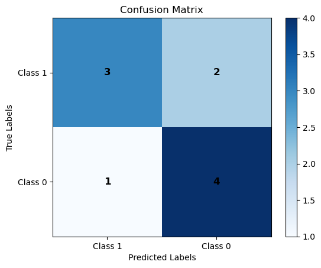

```python
import numpy as np
from sklearn.metrics import confusion_matrix
import matplotlib.pyplot as plt

# Assuming y_train and y_pred_train are your true labels and predicted labels
y_train = np.array([1, 0, 1, 1, 0, 0, 1, 0, 0, 1])
y_pred_train = np.array([1, 0, 1, 1, 0, 1, 0, 1, 0, 1])

# Calculate the confusion matrix
cm = confusion_matrix(y_train, y_pred_train)

# Print confusion matrix
print("Confusion Matrix:")
print(cm)

# Visualize confusion matrix
plt.imshow(cm, cmap=plt.cm.Blues)
plt.title("Confusion Matrix")
plt.colorbar()
plt.xlabel("Predicted Labels")
plt.ylabel("True Labels")

# Set the tick labels
class_labels = ["Class 1", "Class 0"]
plt.xticks(np.arange(len(class_labels)), labels=class_labels)
plt.yticks(np.arange(len(class_labels)), labels=class_labels)

# Add cell values as annotations with darker color
for i in range(len(cm)):
    for j in range(len(cm[0])):
        plt.text(j, i, str(cm[i, j]), ha='center', va='center', color='black', fontsize=12, weight='bold')

plt.show()
```

```
Confusion Matrix:
[[3 2]
 [1 4]]
```

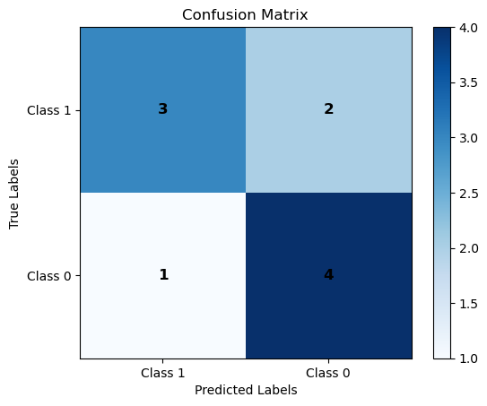

```python
import numpy as np
from sklearn.metrics import confusion_matrix
import matplotlib.pyplot as plt

# Assuming X contains your feature
# cm = confusion_matrix(y_val, y_pred_val)

# Assuming y_val and y_pred_val are your true labels and predicted labels
y_val = np.array([1, 0, 1, 1, 0, 0, 1, 0, 0, 1])
y_pred_val = np.array([1, 0, 1, 1, 0, 1, 0, 1, 0, 1])

# Calculate the confusion matrix
cm = confusion_matrix(y_val, y_pred_val)

# Print confusion matrix
print("Confusion Matrix:")
print(cm)

# Visualize confusion matrix
plt.imshow(cm, cmap=plt.cm.Blues)
plt.title("Confusion Matrix")
plt.colorbar()
plt.xlabel("Predicted Labels")
plt.ylabel("True Labels")

# Set the tick labels
class_labels = ["Class 1", "Class 0"]
plt.xticks(np.arange(len(class_labels)), labels=class_labels)
plt.yticks(np.arange(len(class_labels)), labels=class_labels)

# Add cell values as annotations with darker color
for i in range(len(cm)):
    for j in range(len(cm[0])):
        plt.text(j, i, str(cm[i, j]), ha='center', va='center', color='black', fontsize=12, weight='bold')

plt.show()
```

```python
import pandas as pd

# Assuming y_train is a NumPy array
y_train_series = pd.Series(y_train)

# Now you can use value_counts()
value_counts = y_train_series.value_counts()
print(value_counts)
```

```
1    5
0    5
Name: count, dtype: int64
```